# Corona - Fallzahlenauswertung

### Datenquelle, Abrufzeitpunkt

[Link zur Datenbeschreibung des RKI](https://www.arcgis.com/home/item.html?id=dd4580c810204019a7b8eb3e0b329dd6)

| Amtliche RKI-Corona-Daten für Land-/Stadtkreis | Abrufzeitpunkt |
| --- | --- |
| Passau, Landkreis | Dienstag, 20.04.2021, 07:23:11 |

### Inzidenzrelevanter Zeitraum

| von - bis | nicht mehr in der Inzidenzzahl |
| --- | --- |
| Di, 13.04.2021 - Mo, 19.04.2021 | Mo, 12.04.2021 und älter |

### Veränderungen zum Vortag

```
##  Meldedatum Art Inzidenzrelevant Fallzahl A05-A14 A15-A34 A60-A79
##  2021-04-18 Neu               Ja        1       1       0       0
##  2021-04-19 Neu               Ja        3       0       2       1
```

### Altersstruktur der aktuellen 7-Tage-Inzidenzfälle

```
##  A00-A04 A05-A14 A15-A34 A35-A59 A60-A79 A80+ unbekannt
##       14      33      86     112      37    8         1
```

### Neu gemeldete Fälle je Tag seit 01.01.2021

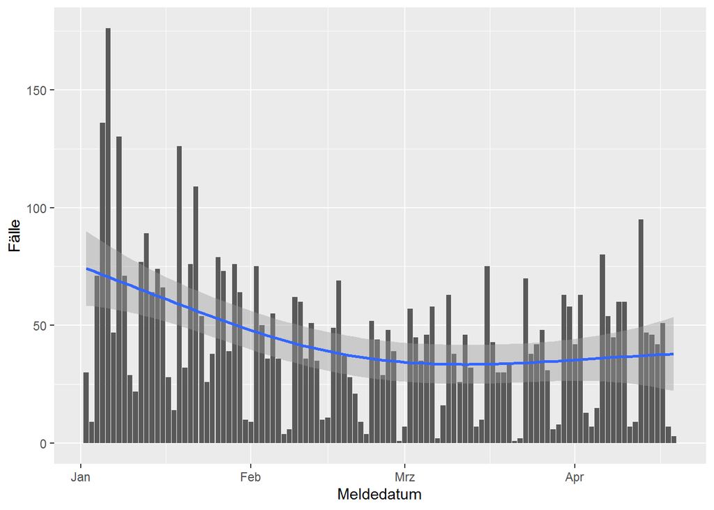

### Wochenübersicht

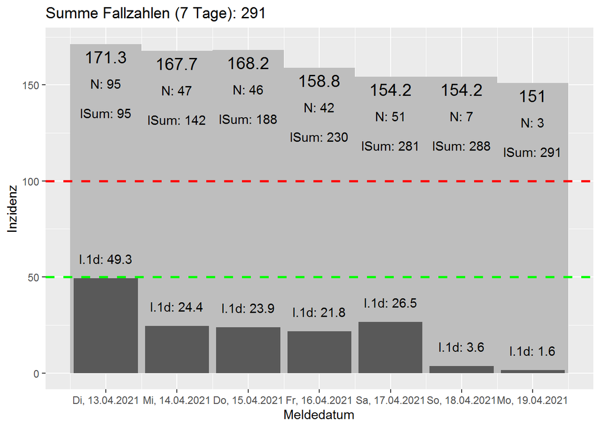

Erläuterung der Zahlenangaben:  
**N**: Anzahl der neu und nachträglich gemeldeten abzüglich der gestrichenen Fälle des jeweiligen Tages  
**I.1d** (“1-Tages-Inzidenz”): Höhe des Beitrags, den dieser Tag zur Wocheninzidenz leistet  
**lSum**: Aggregierte Summe der Fallzahlen über den Verlauf der beobachteten Woche. Der erste Tag entspricht diesem einzelnen Tag (und fällt als nächstes aus der Inzidenz), der letzte Tag entspricht der Wochen-Inzidenz.

### Über-/Unterschreitungen der geltenden Grenzwerte

```
##  Grenzwert bei_Fallzahl Abweichung
##         50           96       +195
##        100          192        +99
```

### Gesicherter Ausblick (absehbare Streichungen)

Aktuelle Inzidenz: 151, basierend auf den insgesamt 291 Fällen der letzten Woche.

| Stichtag | Streichtag | kum. Fallzahl | kum. Inzidenz | max. Rückgang auf |
| --- | --- | --- | --- | --- |
| Morgen | 13.04.2021 | -95 | -49.3 | 101.8 |
| Übermorgen | 14.04.2021 | -142 | -24.4 | 77.4 |
| In drei Tagen | 15.04.2021 | -188 | -23.9 | 53.5 |

Die Fallzahlen der nächsten Tage sowie eventuelle Nachmeldungen sind dabei nicht vorhersehbar. Der maximale Rückgang wird nur erreicht, wenn bis zu diesem Tag per Saldo kein neuer Fall erfasst wird.

### Ungesicherter Ausblick

Fallzahlen gehen je nach Wochentag in unterschiedlicher Höhe ein. Basierend auf den letzten 3 Wochen bzw. 21 Tagen ergibt sich folgende Verteilung:

```
##   Wochentag Mittelwert
##     Sonntag       7.00
##      Montag       9.00
##    Dienstag      79.33
##    Mittwoch      53.00
##  Donnerstag      44.33
##     Freitag      55.00
##     Samstag      41.33
```

…auf der Grundlage folgender Fallzahlen der letzten 3 Wochen:

```
##  Meldedatum AnzahlFall  Wochentag
##  2021-03-30         63   Dienstag
##  2021-03-31         58   Mittwoch
##  2021-04-01         42 Donnerstag
##  2021-04-02         63    Freitag
##  2021-04-03         13    Samstag
##  2021-04-04          7    Sonntag
##  2021-04-05         15     Montag
##  2021-04-06         80   Dienstag
##  2021-04-07         54   Mittwoch
##  2021-04-08         45 Donnerstag
##  2021-04-09         60    Freitag
##  2021-04-10         60    Samstag
##  2021-04-11          7    Sonntag
##  2021-04-12          9     Montag
##  2021-04-13         95   Dienstag
##  2021-04-14         47   Mittwoch
##  2021-04-15         46 Donnerstag
##  2021-04-16         42    Freitag
##  2021-04-17         51    Samstag
##  2021-04-18          7    Sonntag
##  2021-04-19          3     Montag
```

### Blick in die Kristallkugel

Hier werden drei verschiedene Szenarien dargestellt:  
* Optimistische Variante 0 (Grün): Es treten keine Fälle mehr auf, somit dauert es noch 7 Tage, bis alle Inzidenzfälle abgeschmolzen sind.  
* Realistische Variante 1 (schwarz): Täglich kommen die durchschnittlichen Fälle für den jeweiligen Wochentag hinzu, was dem Abschmelzen aus Variante 0 entgegenwirkt.  
* Pessimistische Variante 2 (Rot): Wie Variante 1, nur kommt täglich der DOPPELTE Durchschnitt für den jeweiligen Wochentag hinzu. Dieser Zuwachs stellt keineswegs das obere Limit des möglichen dar.

**Bitte beachten: Im Folgenden stellt die Zeitachse das Veröffentlichungsdatum dar, nicht das Meldedatum, und ist somit um einen Tag verschoben!**

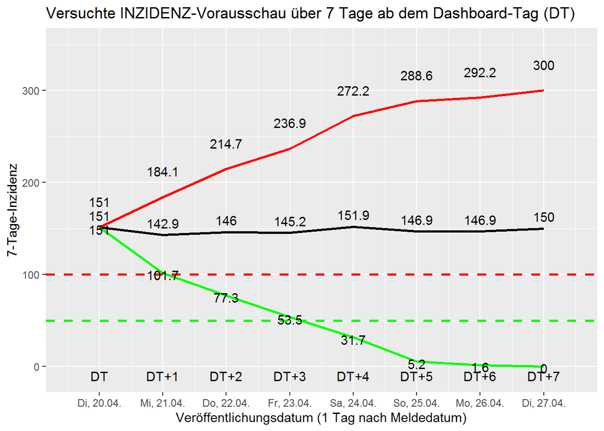

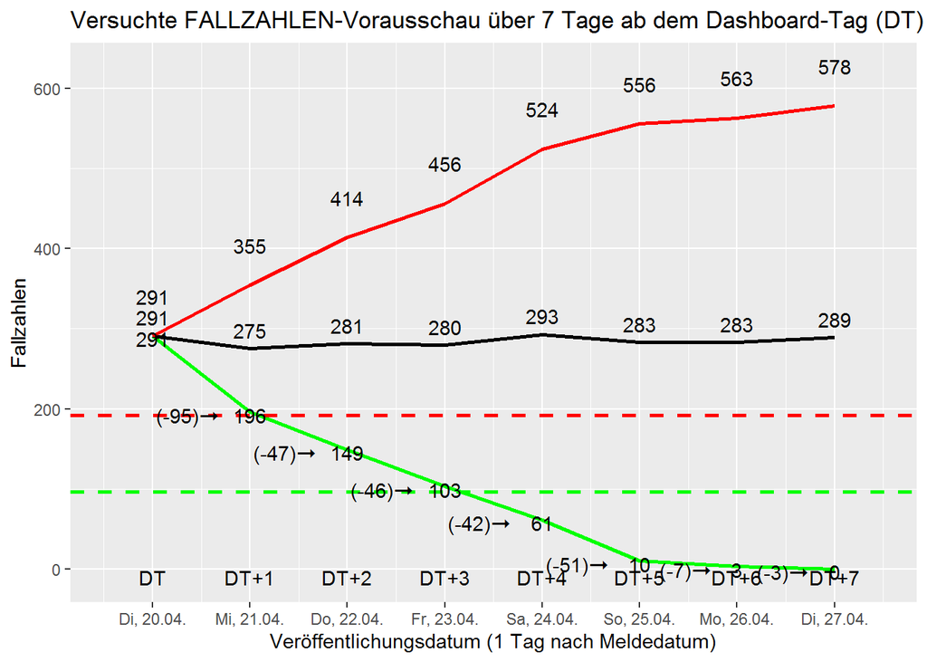